# PC GP02 01

- Pig: 38.8 kg
- Hole (max) 12.6 mm. 3 hits at 35 deg:
1. Hit 1: 8.42 atm, ICP from 8 to 19 at 15:41 pm
2. Hit 2: 6.59 atm, ICP from 12 to 18 at 15:42 pm
3. Hit 3: 6.43 atm, ICP from 14 to 22 at 15:43 pm

At 16h, brain was hyperemic and ventricles enlarged.  
At 24h, blood brain barrier leaked.

## Cooling set up

1st target = -10 deg (VT output air)  
Flow rate = 60 SLPM  
2nd target = 32 deg (brain temp to cool down to)  
Maintenance time = 920 min once brain reached 33 deg  
3rd target temperature = 37 deg (rewarm target)  
Rewarm rate = 0.25 deg/h

| Scan time | Description |
| --- | --- |
| 13:00 | Baseline before Drill |
| 15:02 | Baseline drilled |
| 15:25 | Baseline adaptor in |
| 15:57 | 15 min post |
| 16:12 | 30 min post |
| 16:42 | 60 min post |
| 17:12 | 90 min post |
| 17:52 | 2h post |
| 18:42 | 3h post |
| 19:42 | 4h post |
| 20:44 | Brain temp: 32 deg |
| 21:09 | Cooling unit stopped |
| 21:42 | 6h post |
| 23:42 | 8h post |
| 01:42 | 10h post |
| 03:42 | 12h post |
| 07:42 | 16h post |
| 07:52 | Rewarm |
| 09:44 | 18h post |
| 10:42 | 19h post |
| 11:42 | 20h post |
| 12:42 | 21h post |
| 13:42 | 22h post |
| 14:42 | 23h post |
| 15:42 | 24h post |

## Plots

Study ended at 15:42 pm (24h).

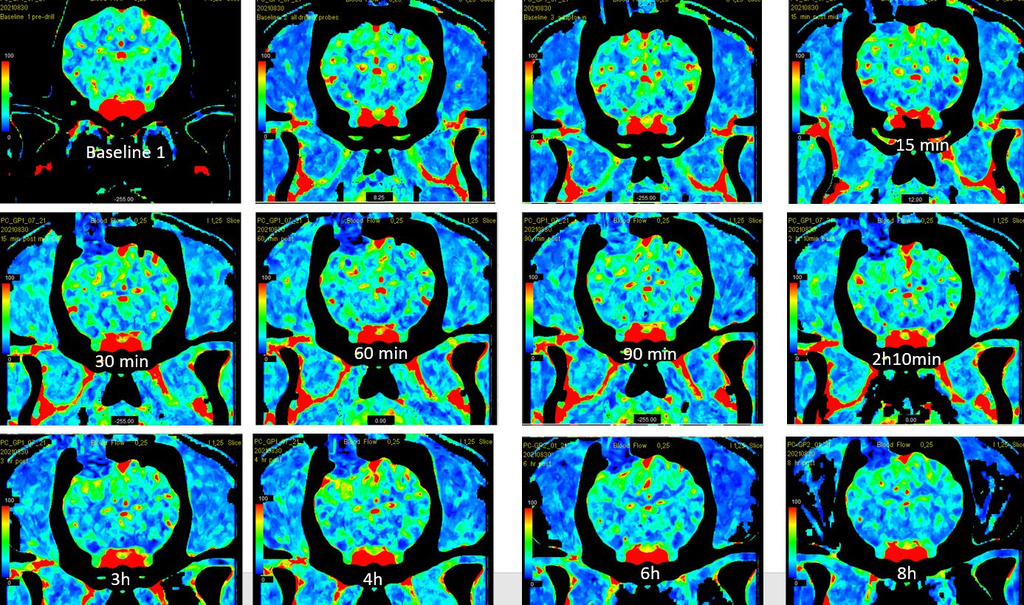

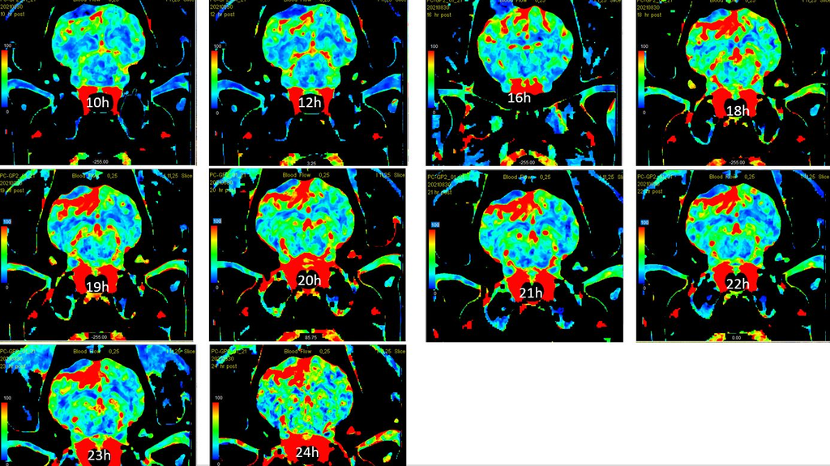

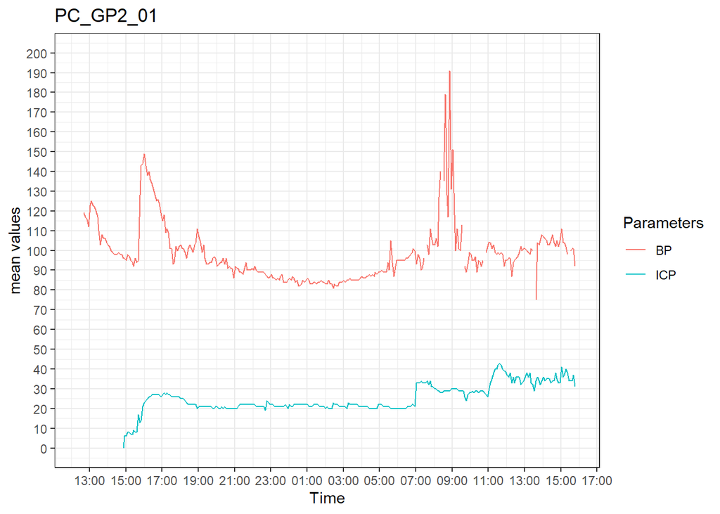

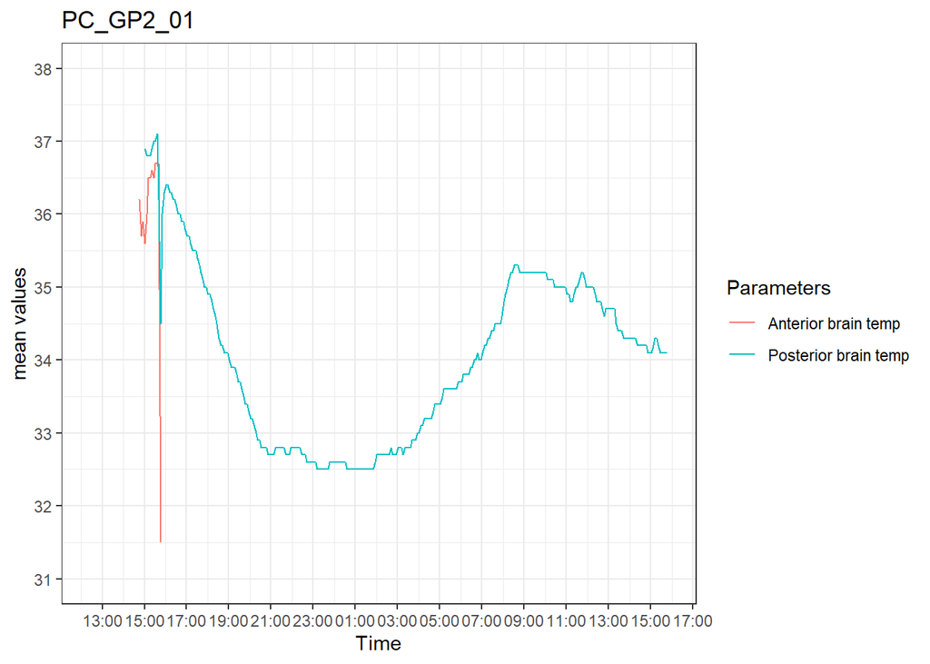

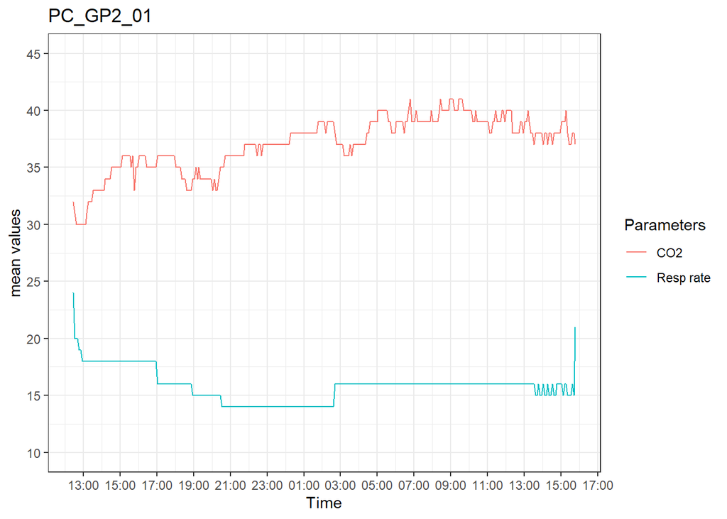

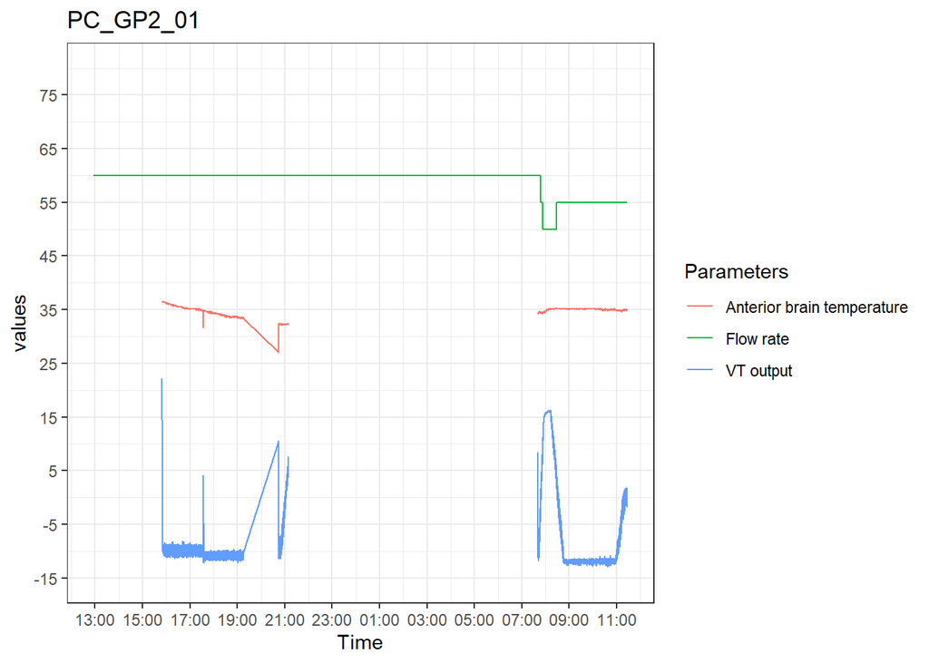

## TTC

[figure not shown]